# Final Exam Answer Key

## Instructions

This exam is open book and open note.

Complete the following and send via email to Prof. Hazelett timestamped by 3 PM today (June 11, 2020). **Include your last name in the file name ( *e.g.* “HAZELETT_FINAL.html”).** Use your assigned TF for all analyses unless otherwise indicated. **If your factor has two batches associated, use batch A only**. Submit your completed exam in html format. Make sure to review your work before submitting. Total points = 30.

Note that the answer key contains seperate tabs for each question.

### 1

#### 1A

Using the TF assigned to you for this exam, generate the data and model files you need for differential expression analysis in GENAVi. Load the data into GENAVi, and using the raw counts table, select your target transcription factor and $\beta$-Actin (gene symbol: `ACTB`). Now, using **the first of the two replicates** for knock-down and control and one of the enrichment methods we learned in class, answer the question: is your knockdown target differentially expressed (relative to $\beta$-Actin)? Show your work in the code block. **(3 pts)**

There are 3 steps to solving this problem. I will use TEAD2 factor as an example since everyone was working with a different transcription factor.

Step 1) extract the count data for both genes from your treatment and control samples.

Using code from assignment 1, extract a count matrix and model file for loading into GENAVi:

```r
### your code here

## Let's open the metadata file
setwd(course_directory)
metadat <- read.csv(
  file = file.path(course_directory, 'data', 'crispri_modelmatrix.csv'),
  header = TRUE,
  stringsAsFactors = FALSE)

genesymbol <- 'TEAD2'
genebatch <- metadat$batch[metadat$treatment==genesymbol][1]

gene.metadat <- rbind(
  subset(
    subset(metadat, treatment == genesymbol),
    batch == genebatch),
  subset(
    subset(metadat, treatment == 'CRISPRi_CONTROL'),
    batch == genebatch)
  )

gene.samples <- gene.metadat$samples

## Now we read in the data from feature counts file
cts <- read.csv(
  file = file.path(course_directory, 'data', 'combinedfeatcounts.csv'),
  header = TRUE,
  stringsAsFactors = FALSE)

## We need to select the columns from our tead.samples, including the Geneid column:

gene.counts <- subset(cts, select = c("Geneid", gene.samples))

## Now we're ready to export these object for upload to GENAVi
# write.table(
#   gene.counts,
#   file = file.path(course_directory, 'data',
#                    paste(genesymbol, 'featcounts.csv', sep = '')),
#   row.names = FALSE,
#   quote = FALSE,
#   sep = ','
# )
#
# write.table(
#   gene.metadat,
#   file = file.path(course_directory, 'data',
#                    paste(genesymbol, 'model.csv', sep = '')),
#   row.names = FALSE,
#   quote = FALSE,
#   sep = ','
# )
```

Explain your answer here, including the read count numbers from GENAVi used to plug into any code you’ve written.

After loading into GENAVi and extracting the values for TEAD2 & Actin B in treatment and control, I have the following count matrix:

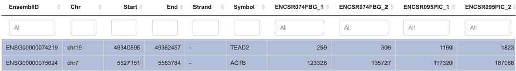

1 point of partial credit for completing this step.

Step 2) Choose the correct method–comparison of proportions. 1 point of partial credit.

Step 3) Determine whether the target transcription factor gene was differentially expressed. We want to compare the expression of a gene of interest, TEAD2, in treatment *vs.* control. In order to do this, it is necessary to make a comparison with the control gene, Actin B, in analagous fashion to how we would calculate gene expression from an RT-PCR experiment. We first estimate the relative fraction of TEAD2 *vs.* Actin B using the beta distribution, then compare the relative fractions. Finally, we confirm whether the 95% credible range includes 0 (the null hypothesis).

```r
# using only the first replicate
# 'alpha' parameter is TEAD2 counts
# 'beta' parameter is ACTB counts
treatment <- rbeta(1e5, 259, 123328)
control   <- rbeta(1e5, 1160, 117320)
treatment_vs_control <- treatment - control
quantile(treatment_vs_control, p=c(0.0275, 0.975))
```

```
##        2.75%        97.5%
## -0.008301038 -0.007092915
```

This result can be interpreted as meaning that expression of TEAD 2 changed by as little as 7 tenths of a percent and as much as 8 tenths of a percent of Actin B expression levels in treatment *vs.* control.

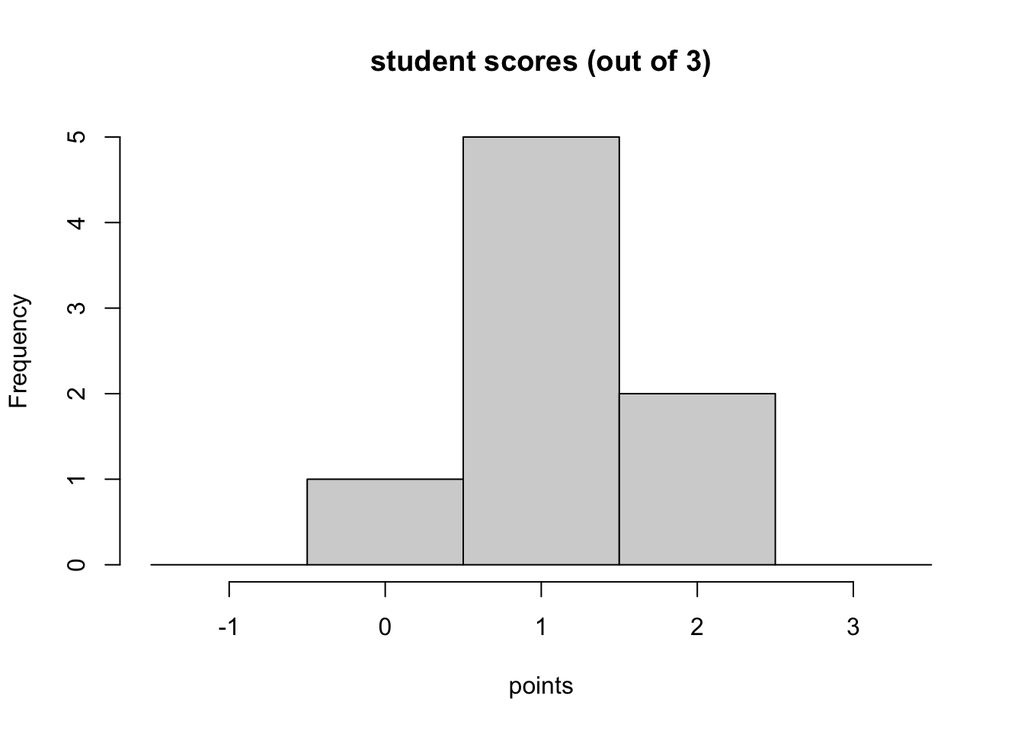

#### 1B

Calculate the FPKM for your TF in both replicates and controls using R. **(2 pts)**

To answer this question, we need two pieces of information: the depth of coverage in the experiment, and the gene length in b.p. We gave 1 point for using the correct formula, and 1 point for the correct answer.

```r
### your code here
# gene length obtained from UCSC genome browser: (also obtainable from the GTF file in Q2)
gene_length <- 21862
replicate_depth <- colSums(gene.counts[,-1])
tead2_treatment_rep1 <- 259 * 1e3 * 1e6 / (replicate_depth[1] * gene_length)
tead2_treatment_rep2 <- 306 * 1e3 * 1e6 / (replicate_depth[2] * gene_length)
tead2_control_rep1 <- 1160 * 1e3 * 1e6 / (replicate_depth[3] * gene_length)
tead2_control_rep2 <- 1823 * 1e3 * 1e6 / (replicate_depth[4] * gene_length)
tead2_treatment_rep1
```

```
## ENCSR074FBG_1
##      0.261047
```

```r
tead2_treatment_rep2
```

```
## ENCSR074FBG_2
##     0.3004807
```

```r
tead2_control_rep1
```

```
## ENCSR095PIC_1
##      1.505989
```

```r
tead2_control_rep2
```

```
## ENCSR095PIC_2
##      1.453909
```

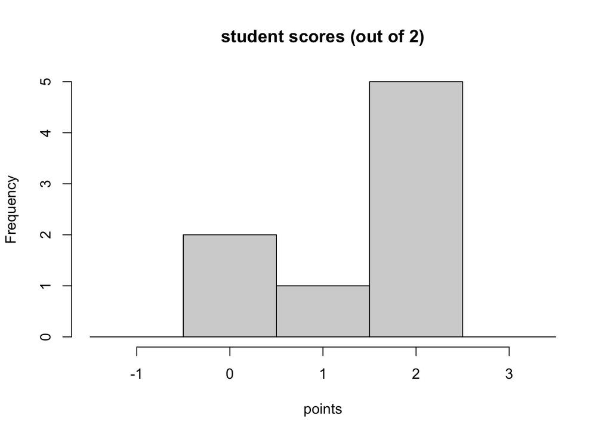

#### 1C

Here is a GTF for all the transcription factors of the CRISPRi experiment.

```
chr1    HAVANA  gene    11012344    11025739    .   +   .   gene_id "ENSG00000120948.18"; gene_type "protein_coding"; gene_name "TARDBP"; level 2; hgnc_id "HGNC:11571"; tag "overlapping_locus"; havana_gene "OTTHUMG00000002120.1";
chr1    HAVANA  gene    26472440    26476642    .   +   .   gene_id "ENSG00000198830.11"; gene_type "protein_coding"; gene_name "HMGN2"; level 2; hgnc_id "HGNC:4986"; havana_gene "OTTHUMG00000003555.1";
chr1    HAVANA  gene    150926263   150964744   .   +   .   gene_id "ENSG00000143379.12"; gene_type "protein_coding"; gene_name "SETDB1"; level 1; hgnc_id "HGNC:10761"; havana_gene "OTTHUMG00000035003.1";
chr1    HAVANA  gene    151340640   151347357   .   -   .   gene_id "ENSG00000143390.17"; gene_type "protein_coding"; gene_name "RFX5"; level 1; hgnc_id "HGNC:9986"; havana_gene "OTTHUMG00000012495.1";
chr1    HAVANA  gene    153661788   153671028   .   -   .   gene_id "ENSG00000143621.17"; gene_type "protein_coding"; gene_name "ILF2"; level 2; hgnc_id "HGNC:6037"; havana_gene "OTTHUMG00000037087.1";
chr1    HAVANA  gene    161039251   161045977   .   -   .   gene_id "ENSG00000158773.14"; gene_type "protein_coding"; gene_name "USF1"; level 1; hgnc_id "HGNC:12593"; havana_gene "OTTHUMG00000031472.1";
chr1    HAVANA  gene    185045526   185102603   .   +   .   gene_id "ENSG00000121481.11"; gene_type "protein_coding"; gene_name "RNF2"; level 2; hgnc_id "HGNC:10061"; havana_gene "OTTHUMG00000035391.1";
chr1    HAVANA  gene    203795654   203854999   .   +   .   gene_id "ENSG00000058673.16"; gene_type "protein_coding"; gene_name "ZC3H11A"; level 2; hgnc_id "HGNC:29093"; tag "overlapping_locus"; havana_gene "OTTHUMG00000035909.1";
chr1    HAVANA  gene    212565334   212620777   .   +   .   gene_id "ENSG00000162772.17"; gene_type "protein_coding"; gene_name "ATF3"; level 2; hgnc_id "HGNC:785"; havana_gene "OTTHUMG00000036747.1";
chr2    HAVANA  gene    172084740   172089677   .   +   .   gene_id "ENSG00000144355.15"; gene_type "protein_coding"; gene_name "DLX1"; level 1; hgnc_id "HGNC:2914"; havana_gene "OTTHUMG00000073951.1";
chr2    HAVANA  gene    190908460   191020960   .   -   .   gene_id "ENSG00000115415.20"; gene_type "protein_coding"; gene_name "STAT1"; level 1; hgnc_id "HGNC:11362"; tag "overlapping_locus"; havana_gene "OTTHUMG00000132699.1";
chr3    HAVANA  gene    14947584    15053600    .   +   .   gene_id "ENSG00000177463.15"; gene_type "protein_coding"; gene_name "NR2C2"; level 1; hgnc_id "HGNC:7972"; havana_gene "OTTHUMG00000129839.1";
chr3    HAVANA  gene    69739435    69968337    .   +   .   gene_id "ENSG00000187098.15"; gene_type "protein_coding"; gene_name "MITF"; level 2; hgnc_id "HGNC:7105"; havana_gene "OTTHUMG00000149921.1";
chr3    HAVANA  gene    128479427   128493201   .   -   .   gene_id "ENSG00000179348.12"; gene_type "protein_coding"; gene_name "GATA2"; level 2; hgnc_id "HGNC:4171"; havana_gene "OTTHUMG00000159689.1";
chr3    HAVANA  gene    177019340   177228000   .   -   .   gene_id "ENSG00000177565.18"; gene_type "protein_coding"; gene_name "TBL1XR1"; level 2; hgnc_id "HGNC:29529"; tag "ncRNA_host"; havana_gene "OTTHUMG00000157140.1";
chr4    HAVANA  gene    1211448 1249953 .   -   .   gene_id "ENSG00000159692.15"; gene_type "protein_coding"; gene_name "CTBP1"; level 1; hgnc_id "HGNC:2494"; havana_gene "OTTHUMG00000089259.1";
chr4    HAVANA  gene    1871393 1982207 .   +   .   gene_id "ENSG00000109685.18"; gene_type "protein_coding"; gene_name "NSD2"; level 2; hgnc_id "HGNC:12766"; tag "ncRNA_host"; tag "overlapping_locus"; havana_gene "OTTHUMG00000121147.1";
chr4    HAVANA  gene    173331376   173334432   .   -   .   gene_id "ENSG00000164104.12"; gene_type "protein_coding"; gene_name "HMGB2"; level 2; hgnc_id "HGNC:5000"; havana_gene "OTTHUMG00000160799.1";
chr5    HAVANA  gene    136132845   136188747   .   +   .   gene_id "ENSG00000113658.18"; gene_type "protein_coding"; gene_name "SMAD5"; level 2; hgnc_id "HGNC:6771"; tag "ncRNA_host"; havana_gene "OTTHUMG00000163212.1";
chr5    HAVANA  gene    177301461   177312757   .   -   .   gene_id "ENSG00000213347.10"; gene_type "protein_coding"; gene_name "MXD3"; level 2; hgnc_id "HGNC:14008"; tag "overlapping_locus"; havana_gene "OTTHUMG00000130854.1";
chr6    HAVANA  gene    34236873    34246231    .   +   .   gene_id "ENSG00000137309.20"; gene_type "protein_coding"; gene_name "HMGA1"; level 2; hgnc_id "HGNC:5010"; tag "ncRNA_host"; havana_gene "OTTHUMG00000014539.1";
chr6    HAVANA  gene    41072945    41099976    .   +   .   gene_id "ENSG00000001167.14"; gene_type "protein_coding"; gene_name "NFYA"; level 2; hgnc_id "HGNC:7804"; havana_gene "OTTHUMG00000014669.1";
chr6    HAVANA  gene    43171269    43181506    .   +   .   gene_id "ENSG00000112658.8"; gene_type "protein_coding"; gene_name "SRF"; level 2; hgnc_id "HGNC:11291"; havana_gene "OTTHUMG00000014722.1";
chr6    HAVANA  gene    79201245    79234738    .   -   .   gene_id "ENSG00000118418.14"; gene_type "protein_coding"; gene_name "HMGN3"; level 2; hgnc_id "HGNC:12312"; havana_gene "OTTHUMG00000015073.1";
chr6    HAVANA  gene    139371807   139374648   .   -   .   gene_id "ENSG00000164442.10"; gene_type "protein_coding"; gene_name "CITED2"; level 2; hgnc_id "HGNC:1987"; havana_gene "OTTHUMG00000015691.1";
chr7    HAVANA  gene    129611720   129757082   .   +   .   gene_id "ENSG00000106459.15"; gene_type "protein_coding"; gene_name "NRF1"; level 2; hgnc_id "HGNC:7996"; tag "ncRNA_host"; havana_gene "OTTHUMG00000143736.1";
```

[output cut: 48 more lines]

Convert the GTF entry for your TF into a BED entry with 6 fields. **(3 pts)**

[output not shown]

1 point for identifying your TF in the GTF file. 1 point for showing **any** valid bed formatted line in your answer. 1 point for remembering that bed files are 0-based *vs.* GTFs 1-based for the start coordinate.

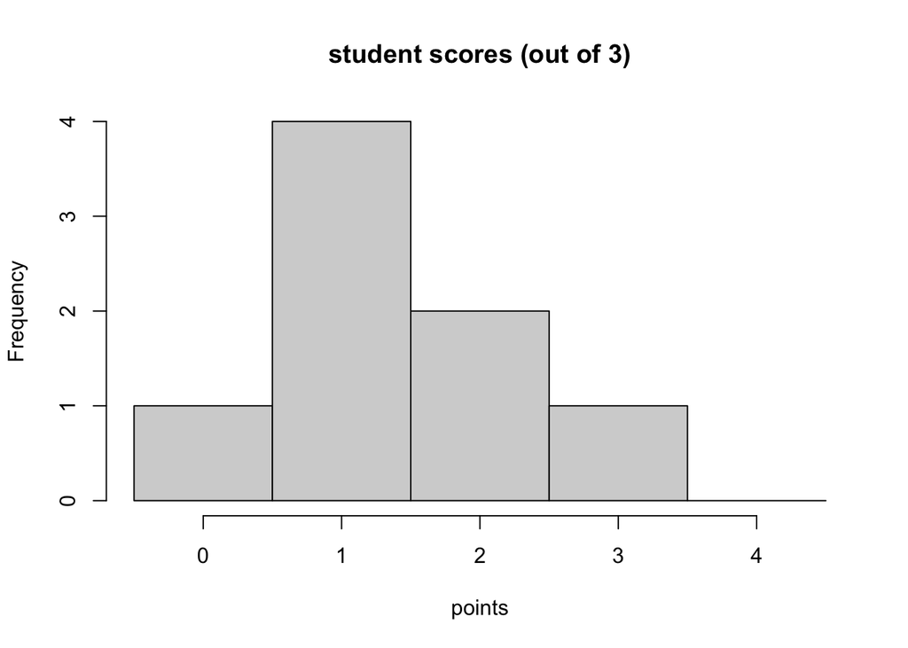

### 2

Perform DEA analysis for the knockdown of your assigned transcription factor. Using a log-fold change cutoff of 0.5 and fdr of 0.05, how many differentially expressed genes are there? **(4 pts)**

Enter your answers here.

Due to the difficulty/ambiguity of applying the LFC cutoff simultaneously with fdr, we gave 3 points for *any* answer, 1 point for being in the ballpark of the correct answer. The numbers in the table below reflect the answer you might obtain from the volcano plot, whereas GENAVi’s download function would give you more significant genes by an order of magnitude. We gave full credit for either answer.

```r
#   experiment                           sig_genes
#   <chr>                                    <int>
# 1 treatment_HINFP_vs_CRISPRi_CONTROL         320
# 2 treatment_ZNF384_vs_CRISPRi_CONTROL        187
# 3 treatment_STAT1_vs_CRISPRi_CONTROL         147
# 4 treatment_SRF_vs_CRISPRi_CONTROL           142
# 5 treatment_UBTF_vs_CRISPRi_CONTROL           29
# 6 treatment_ZC3H11A_vs_CRISPRi_CONTROL        22
# 7 treatment_NSD2_vs_CRISPRi_CONTROL           13
# 8 treatment_HOXB9_vs_CRISPRi_CONTROL          12

dea <- read.csv(
  file = file.path(course_directory, 'data', 'GENAVi_DEA_results_files', 'treatment_TEAD2_vs_CRISPRi_CONTROL.csv'),
  row.names = 1
  )

nrow(subset(dea, padj < 0.05 & abs(log2FoldChange) >= 0.5))
```

```
## [1] 6206
```

Save your volcano plot and include it here (add an exclamation point at the start of the line to activate the link): **(1 pt)**

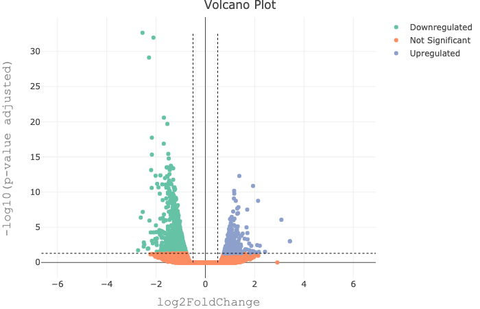

Volcano Plot

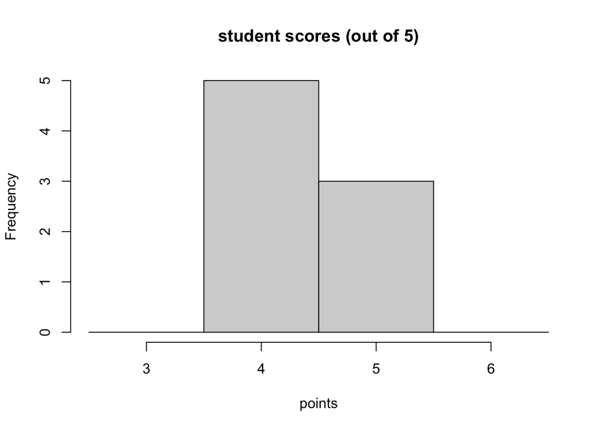

### 3

Using GENAVi, produce a principle components analysis for your TF and include the PCA plot below. **(1 pt)**

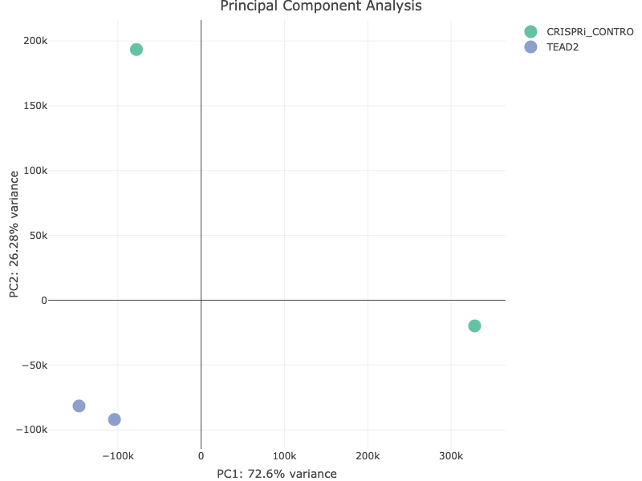

PCA Plot

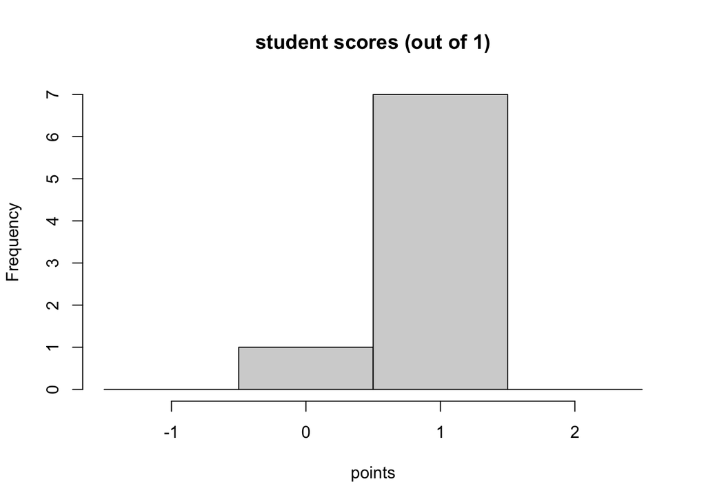

### 4

Identify the samples for your assigned TF in the MultiQC html document for the class. Are any of the samples poor enough to exclude? **(2 pts)** Justify your answer in terms of metrics from the multiQC and relate your findings to the PCA plot from **Question 3**. **(3 pts)**

Enter your answers here.

The answer to this question varies by transcription factor, and reasonable arguments could be made for excluding one of the control replicates or keeping both. We gave two points for making any reasonable case here. The remaining 3 points were given for including discussions of relevant aspects of MultiQC and PCA plots in your justification.

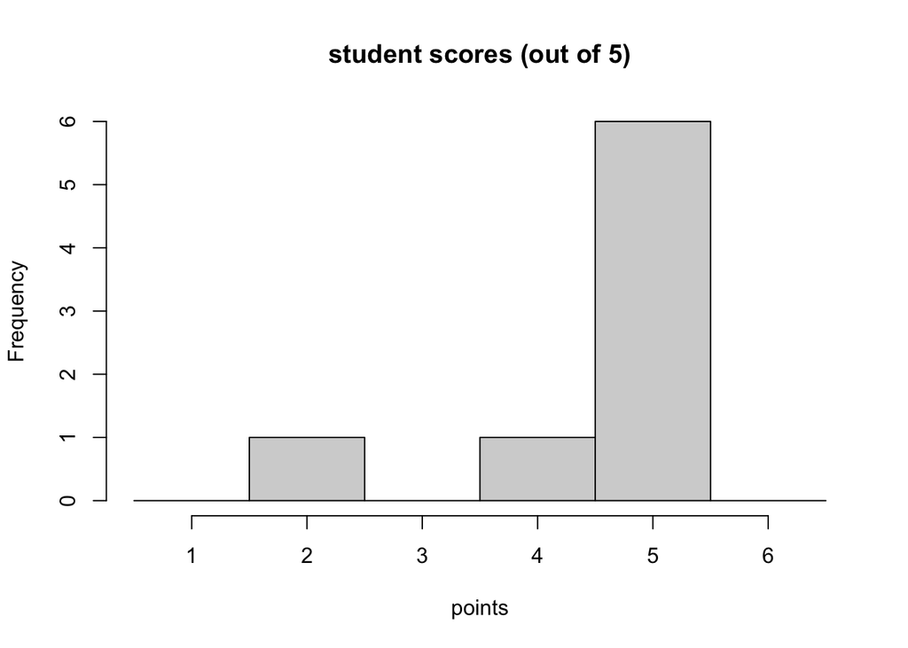

### 5

A colleague hands you an excel spreadsheet with FPKM values for an *RNA-seq* experiment. Change all **incorrect** answers to **red**: **(6 pts)**

- You may assume this is a paired end workflow. **TRUE:** although fpkm is frequently incorrectly applied to non-paired end datasets, in an ideal world “fragments” implies PE.
- You can reverse-engineer the depth of coverage using summary statistics. **FALSE:** there is no information about the depth of coverage in fpkm values.
- The data are normalized. **TRUE:** individual gene expression values are normalized by depth of coverage and gene length.
- No further normalization is possible. **FALSE:** global transforms ( *e.g.* scale and median normalizations) are still possible.
- If the gene labels are from ENSEMBL, you can tell what organism was used. **TRUE:** ENSEMBL gene labels are unique to each genome, regardless of status as an ortholog of other genes in other genomes.
- Gene expression values are biased by gene length. **FALSE:** fpkm reports the reads per kb of transcript, thus removing bias due to varying gene length.

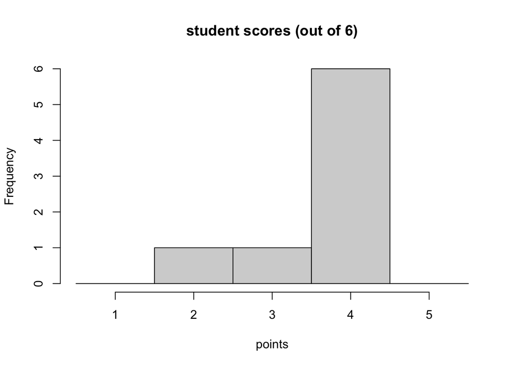

### 6

You are performing RNA-seq analysis on highly rearranged tumors that may have many novel transcripts. The sequencing is very deep ~400,000,000 reads. Which method would you use to assign reads to genes? Support your answer. **(5 pts)**

Enter your answers here.

Full credit was given for alignment + counting, explaining lack of *a priori* gene models, better understanding of alternative splicing, better detection of fusion genes due to genomic alignment. Partial credit was given for choosing mapping if you could rationalize those biases against speed. Did you discuss the pitfalls in the context of mapping against a known transcriptome when tumors are rearranged. 2 points for choosing alignment, 3 points for accurately justifying either.

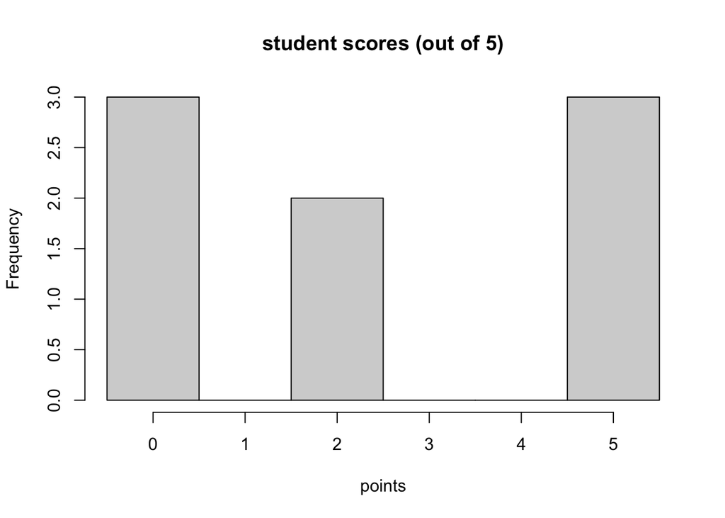

### Grades

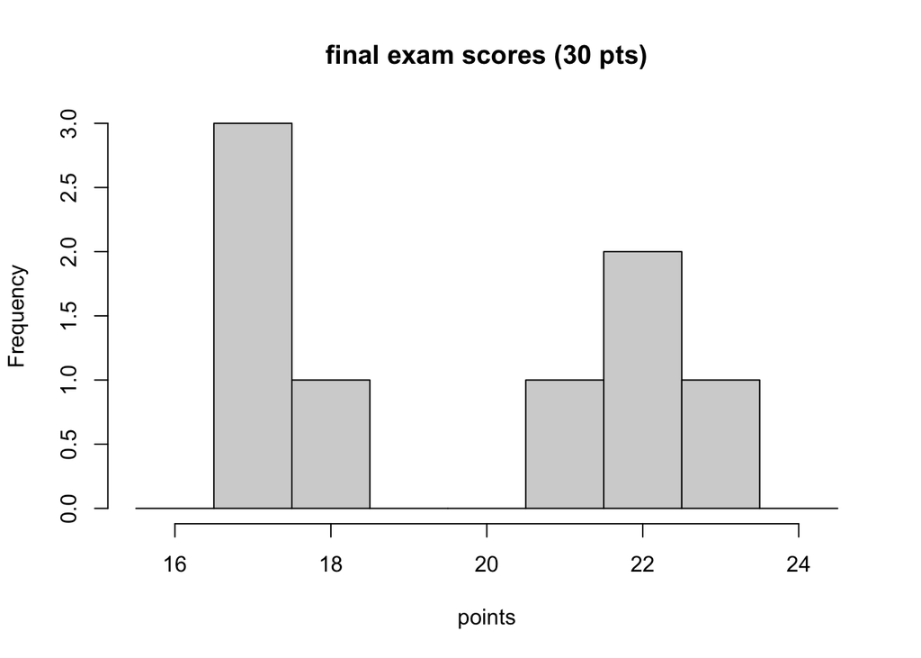

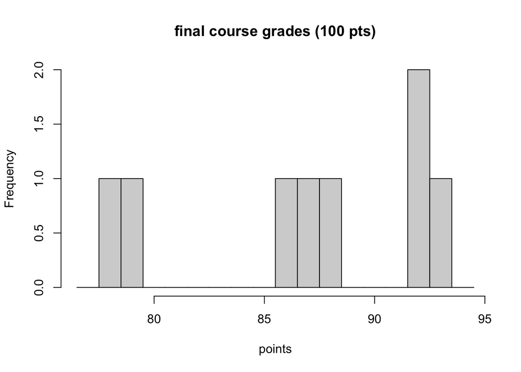